# Avocado Oil Authenticity

Author

Jo Hardin

Published

October 6, 2026

# Avocado Oil Authenticity

This week we’re exploring avocado oil authenticity data from UC Davis researchers. The dataset includes two studies: one from 2020 examining bottled avocado oils and one from 2026 examining processed foods made with avocado oil. The studies reveal widespread fraud in the avocado oil market. The 2020 study found that 82% of bottled avocado oils were either rancid or adulterated with cheaper oils like soybean oil. Six years later, the problem had spread to processed foods: 89% of chips, mayonnaise, and salad dressings labeled as “made with avocado oil” failed authenticity testing. By contrast, olive oil products (which have been regulated for decades) were overwhelmingly pure.

The bottled oil dataset includes detailed chemical fingerprints (fatty acid profiles, sterol composition, and vitamin E content) that researchers use to detect fraud. The processed foods dataset tracks which specific brands and product categories passed or failed lot-level testing. Together, these datasets tell the story of a premium food category with almost no consumer protection.

> Consumers are increasingly paying a premium for products made with avocado oil or olive oil. They deserve to get what they pay for and food manufacturers deserve confidence that the ingredients they purchase from suppliers are authentic.

> Selina Wang, Professor of Cooperative Extension, UC Davis Department of Food Science and Technology

Thank you to [Tony Galvan, Golden Dome Data Science](https://github.com/gdatascience) for curating this week’s dataset.

## The data

We are looking at bottles of avocado oil. The data include 22 bottles and whether the bottle is extra virgin, refined, or unspecified in terms of grade. Additionally, the researchers assessed whether the oil was pure or adulterated or suspected to be adulterated. Last, each bottle was either fresh, oxidized, or not avocado oil.

```r
library(tidyverse)
library(ggforce)
library(praise)
```

```r
bottles <- readr::read_csv(
  'https://raw.githubusercontent.com/rfordatascience/tidytuesday/main/data/2026/2026-10-06/avocado_oil_bottles.csv'
)
foods <- readr::read_csv(
  'https://raw.githubusercontent.com/rfordatascience/tidytuesday/main/data/2026/2026-10-06/avocado_oil_processed_foods.csv'
)
```

## Plotting

The following visualization was inspired by [Manish Datt](https://dataviz.manishdatt.com/posts/26A1/). Which characteristics of the bottles are most associated with the other characteristics?

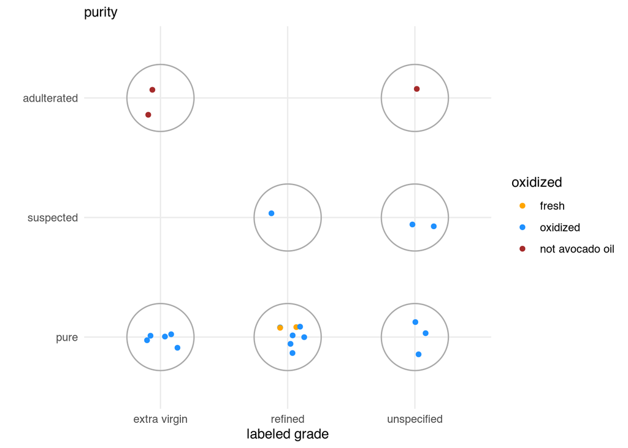

We can see that the adulterated oils are not avocado oil. And the pure oils are almost all oxidized.

```r
set.seed(4747)

bottles |>
  mutate(
    oxidized = case_when(
      is.na(oxidized) ~ "not avocado oil",
      oxidized ~ "oxidized",
      !oxidized ~ "fresh"
    )
  ) |>
  mutate(
    oxidized = fct_relevel(oxidized, c("fresh", "oxidized", "not avocado oil")),
    purity_result = fct_relevel(
      purity_result,
      c("pure", "suspected", "adulterated")
    )
  ) |>
  ggplot(aes(x = grade_labeled, y = purity_result, color = oxidized)) +
  geom_jitter(width = 0.15, height = 0.15) +
  geom_mark_ellipse(
    aes(group = interaction(grade_labeled, purity_result)),
    linetype = "solid",
    linewidth = .5,
    expand = unit(.95, "cm"),
    label.margin = margin(0, 0, 0, 0, "mm"),
    show.legend = FALSE,
    color = "darkgrey"
  ) +
  scale_color_manual(
    values = c(
      "fresh" = "orange",
      "oxidized" = "dodgerblue",
      "not avocado oil" = "brown"
    )
  ) +
  theme_minimal() +
  #theme(legend.position = "none") +
  labs(y = "", x = "labeled grade", subtitle = "purity")
```

```r
praise()
```

```
[1] "You are remarkable!"
```

## Other plots

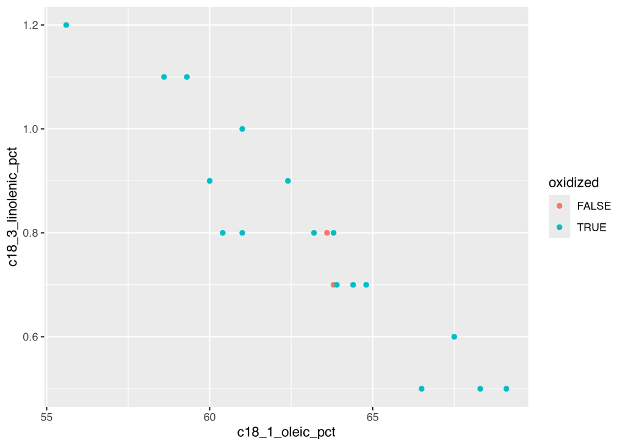

```r
bottles |>
  filter(!is.na(oxidized)) |>
  ggplot(aes(x = c18_1_oleic_pct, y = c18_3_linolenic_pct, color = oxidized)) +
  geom_point()
```